# Lab 4 Team 27

Patrick Wenzel, Kordell Schrock

10/11/2020

```r
library(readxl)
defense <- read_excel('./cyclonesFootball2019.xlsx', sheet='Defensive')
offense <- read_excel('./cyclonesFootball2019.xlsx', sheet='Offensive')
biography <- read_excel('./cyclonesFootball2019.xlsx', sheet='Biography')
str(defense)
```

```
## tibble [502 x 11] (S3: tbl_df/tbl/data.frame)
##  $ Name             : chr [1:502] "White, Lawrence" "White, Lawrence" "White, Lawrence" "White, Lawrence" ...
##  $ Opponent_Opponent: chr [1:502] "UNI" "Iowa" "ULM" "Baylor" ...
##  $ Tackles_Solo     : chr [1:502] "4" "4" "3" "4" ...
##  $ Tackles_ASST     : chr [1:502] "4" "7" "5" "2" ...
##  $ Tackles_TFL      : chr [1:502] "0" "0" "0" "0" ...
##  $ Tackles_Sack     : chr [1:502] "0" "0" "0" "0" ...
##  $ Turnover_FF      : chr [1:502] "0" "0" "0" "0" ...
##  $ Turnover_FR      : chr [1:502] "0" "0" "0" "0" ...
##  $ Turnover_INT     : chr [1:502] "0" "0" "1" "0" ...
##  $ Pass_QBH         : chr [1:502] "1" "0" "0" "0" ...
##  $ Pass_PB          : chr [1:502] "1" "2" "0" "0" ...
```

## Part 1: Cleaning data

```r
offenseClean <- offense %>%
  mutate(Name = factor(Name),
         Opponent_Opponent = factor(Opponent_Opponent)) %>%
  mutate(across(Rushing_ATT:Passing_INT, as.numeric)) #Change to numeric
```

```r
    #cleaning the offense

defenseClean <- defense %>%
  mutate(Name = factor(Name),
         Opponent_Opponent=factor(Opponent_Opponent)) %>%
  mutate(across(Tackles_Solo:Pass_PB, as.numeric)) #Change to numeric
  #cleaning the defense

biographyClean <- biography %>%
  mutate(Weight = as.numeric(Weight)) %>% # Change to numeric column
  separate(Height, c("feet","inches"), "-") %>% # create 2 columns feet and inches from Heights
  mutate(Height = as.numeric(feet)* 12 + as.numeric(inches)) %>% #get numeric inches value from the values of the 2 new columns feet*12 + inches
  select(-feet, -inches)
  #cleaning the biography

str(defenseClean) #print dataset
```

```
## tibble [502 x 11] (S3: tbl_df/tbl/data.frame)
##  $ Name             : Factor w/ 43 levels "Akers, Landen",..: 40 40 40 40 40 40 40 40 40 40 ...
##  $ Opponent_Opponent: Factor w/ 13 levels "Baylor","Iowa",..: 12 2 11 1 8 13 10 7 6 9 ...
##  $ Tackles_Solo     : num [1:502] 4 4 3 4 3 1 7 3 6 5 ...
##  $ Tackles_ASST     : num [1:502] 4 7 5 2 2 1 1 2 1 5 ...
##  $ Tackles_TFL      : num [1:502] 0 0 0 0 1 0 0 0 1 1 ...
##  $ Tackles_Sack     : num [1:502] 0 0 0 0 0 0 0 0 0 1 ...
##  $ Turnover_FF      : num [1:502] 0 0 0 0 0 0 0 0 0 0 ...
##  $ Turnover_FR      : num [1:502] 0 0 0 0 0 0 0 0 0 0 ...
##  $ Turnover_INT     : num [1:502] 0 0 1 0 0 0 0 0 1 0 ...
##  $ Pass_QBH         : num [1:502] 1 0 0 0 0 0 0 0 1 0 ...
##  $ Pass_PB          : num [1:502] 1 2 0 0 0 1 0 0 0 0 ...
```

```r
str(offenseClean) #print dataset
```

```
## tibble [195 x 12] (S3: tbl_df/tbl/data.frame)
##  $ Name             : Factor w/ 17 levels "Akers, Landen",..: 1 1 1 1 1 1 1 1 1 1 ...
##  $ Opponent_Opponent: Factor w/ 13 levels "Baylor","Iowa",..: 12 2 11 1 8 13 10 7 6 9 ...
##  $ Rushing_ATT      : num [1:195] 0 0 1 0 0 0 0 0 0 0 ...
##  $ Rushing_YDS      : num [1:195] 0 0 8 0 0 0 0 0 0 0 ...
##  $ Rushing_TD       : num [1:195] 0 0 0 0 0 0 0 0 0 0 ...
##  $ Receiving_REC    : num [1:195] 1 0 0 0 1 0 0 4 0 1 ...
##  $ Receiving_YDS    : num [1:195] 21 0 0 0 32 0 0 39 0 7 ...
##  $ Receiving_TD     : num [1:195] 0 0 0 0 0 0 0 0 0 0 ...
##  $ Passing_CMP-ATT  : num [1:195] NA NA NA NA NA NA NA NA NA NA ...
##  $ Passing_YDS      : num [1:195] NA NA NA NA NA NA NA NA NA NA ...
##  $ Passing_TD       : num [1:195] NA NA NA NA NA NA NA NA NA NA ...
##  $ Passing_INT      : num [1:195] NA NA NA NA NA NA NA NA NA NA ...
```

```r
str(biographyClean) #print dataset
```

```
## tibble [105 x 7] (S3: tbl_df/tbl/data.frame)
##  $ Name      : chr [1:105] "Akers, Landen" "Allen, Chase" "Anderson, Ezeriah" "Assalley, Connor" ...
##  $ Position  : chr [1:105] "Wide Receiver" "Tight End" "Wide Receiver" "Placekicker" ...
##  $ Weight    : num [1:105] 188 245 204 195 190 235 255 285 300 215 ...
##  $ Class     : chr [1:105] "Redshirt Senior" "Redshirt Senior" "Redshirt Freshman" "Redshirt Senior" ...
##  $ Hometown  : chr [1:105] "Cedar Rapids, Iowa" "Nixa, Mo." "Seffner, Fla." "Naperville, Ill." ...
##  $ Highschool: chr [1:105] "Washington" "Nixa" "Armwood" "Central" ...
##  $ Height    : num [1:105] 72 79 77 72 72 75 74 74 72 78 ...
```

# Part 2: Tidying

## Reformat the defClean data frame into a tidy format using pivot_longer. The type of statistic (Tackles_Solo, Tackles_ASST, etc) is added as a new key column named stat.

```r
#1
defenseClean<-defenseClean %>%
  pivot_longer(Tackles_Solo:Pass_PB, names_to = 'stat')
```

## 2 Compare the distributions of the defensive statistics. What defensive skills are rare?

### 2: While looking at the BarChart we see that TurnOver_FF, TurnOver_FR, and TurnOver_INT are the rarest. Then looking into the Histogram we see again that TurnOver_FF, TurnOver_FR, and TurnOver_INT are the rarest.

```r
#2
sumOfStats <- defenseClean %>%
  group_by(stat) %>% #group by statistics
  summarise(sum = sum(value)) %>% #get the sum
  arrange(sum)

print(sumOfStats) #print the dataset
```

```
## # A tibble: 9 x 2
##   stat           sum
##   <chr>        <dbl>
## 1 Turnover_INT   6
## 2 Turnover_FR    7
## 3 Turnover_FF   10
## 4 Tackles_Sack  25.5
## 5 Pass_QBH      30
## 6 Pass_PB       48
## 7 Tackles_TFL   77
## 8 Tackles_ASST 336
## 9 Tackles_Solo 483
```

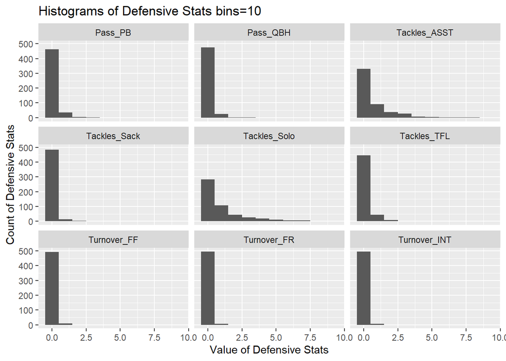

```r
ggplot(defenseClean, aes(x=value)) + geom_histogram(bins=10) + facet_wrap(~stat) + ggtitle('Histograms of Defensive Stats bins=10') + xlab('Value of Defensive Stats') + ylab('Count of Defensive Stats')
```

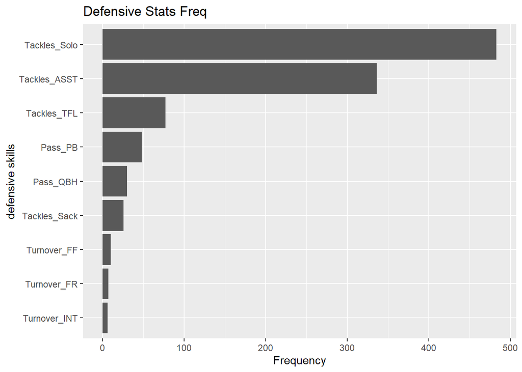

```r
#create histogram of Defensive Stats

ggplot(defenseClean, aes(x = reorder(stat, value), y = value)) + geom_bar(stat = 'identity') + coord_flip() + labs(x = 'defensive skills', y = 'Frequency', title = 'Defensive Stats Freq')
```

```r
#create bar chart of Defensive Stats
```

## 3. Did ISU have better defense against Iowa or Notre Dame? Answer this question by creating a scatterplot with x- and y-axes being the number of solo tackles (of each player). A large number of solo tackles is an indicator of good defense.

### 3: Looking at the Scatter Plot Notre Dame seems to have higher counts of Solo Tackles per player. So Notre Dame must have had a better defence than Iowa. Also looking at the statistical data of aggregating the teams with solo tackles we see again Notre Dame beats Iowa in sum of Tackles and average tackles per player.

```r
#3
iowaVSnotreDame <- defenseClean %>%
  filter(stat == "Tackles_Solo" & (Opponent_Opponent == "Notre Dame" | Opponent_Opponent == "Iowa")) %>% #filter by Solo Tackles and team either Notre Dame or Iowa
  rename(teams = Opponent_Opponent) #rename column

str(iowaVSnotreDame) #display dataframe
```

```
## tibble [77 x 4] (S3: tbl_df/tbl/data.frame)
##  $ Name : Factor w/ 43 levels "Akers, Landen",..: 40 40 29 29 20 20 36 36 7 7 ...
##  $ teams: Factor w/ 13 levels "Baylor","Iowa",..: 2 5 2 5 2 5 2 5 2 5 ...
##  $ stat : chr [1:77] "Tackles_Solo" "Tackles_Solo" "Tackles_Solo" "Tackles_Solo" ...
##  $ value: num [1:77] 4 1 2 5 1 4 1 2 7 2 ...
```

```r
tackles<- aggregate(iowaVSnotreDame$value ~ iowaVSnotreDame$teams , data=iowaVSnotreDame, sum) #aggregate tackles sum per team
averagetackles<- aggregate(iowaVSnotreDame$value ~ iowaVSnotreDame$teams , data=iowaVSnotreDame, mean)#aggregate tackles mean per team
print(tackles) #print Tackles
```

```
##   iowaVSnotreDame$teams iowaVSnotreDame$value
## 1                  Iowa                    30
## 2            Notre Dame                    37
```

```r
print(averagetackles) #print average Tackles
```

```
##   iowaVSnotreDame$teams iowaVSnotreDame$value
## 1                  Iowa             0.7894737
## 2            Notre Dame             0.9487179
```

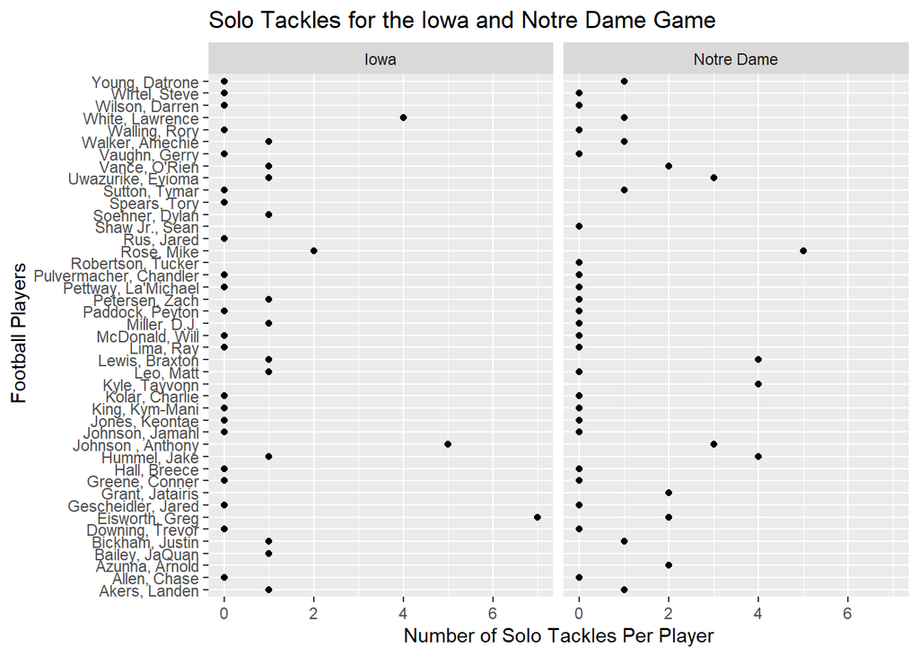

```r
ggplot(iowaVSnotreDame, aes(x = value, y = Name)) + facet_wrap(iowaVSnotreDame$teams) + geom_point() + ggtitle('Solo Tackles for the Iowa and Notre Dame Game') + xlab('Number of Solo Tackles Per Player') + ylab(' Football Players')
```

```r
#Create scater plot of Iowa and Notre Dame Players for Solo Tackles for each player.
# Use facet_wrap() to to show teams variables: Iowa and Notre Dame
```

## 4. Separate the Hometown column into two columns, namely the city and the state. Print the first few rows of these two columns. (Hint: look at the sep= argument of separate)

```r
#4
biographyClean <- biographyClean %>%
  separate(Hometown, c('City', 'State'), sep =", ") #create 2 columns City and State from Hometown.
head(biographyClean) #head of clean biography dataset
```

```
## # A tibble: 6 x 8
##   Name         Position     Weight Class       City      State Highschool Height
##   <chr>        <chr>         <dbl> <chr>       <chr>     <chr> <chr>       <dbl>
## 1 Akers, Land~ Wide Receiv~    188 Redshirt S~ Cedar Ra~ Iowa  Washington     72
## 2 Allen, Chase Tight End       245 Redshirt S~ Nixa      Mo.   Nixa           79
## 3 Anderson, E~ Wide Receiv~    204 Redshirt F~ Seffner   Fla.  Armwood        77
## 4 Assalley, C~ Placekicker     195 Redshirt S~ Napervil~ Ill.  Central        72
## 5 Azunna, Arn~ Defensive B~    190 Redshirt S~ Grand Pr~ Texas Lake Ridge     72
## 6 Bailey, Cor~ Defensive E~    235 Redshirt J~ Clarksda~ Miss. Clarksdale     75
```

## How many players are there from each state?

```r
#5
playersPerState <- biographyClean %>%
      group_by(State) %>% #group by state
      summarize(count = n()) %>% #tally

print(playersPerState) #print dataset
```

```
## # A tibble: 19 x 2
##    State     count
##    <chr>     <int>
##  1 Ariz.         4
##  2 Ark.          1
##  3 Australia     1
##  4 Calif.        3
##  5 Fla.         10
##  6 Ga.           4
##  7 Ill.          5
##  8 Iowa         35
##  9 Kan.          3
## 10 Mich.         4
## 11 Minn.         4
## 12 Miss.         1
## 13 Mo.           6
## 14 Ohio          7
## 15 Okla.         2
## 16 Pa.           1
## 17 S.D.          2
## 18 Texas         6
## 19 Wis.          6
```

## Part Three: Joining Data Frames

1. Find which states do the ISU defensive and offensive players come from. Create an appropriate summary.

```r
defenseNames <- as_tibble_col(unique(defenseClean$Name)) %>% rename(
  Name = value
)

defenseStates <- left_join(x = defenseNames, y = biographyClean, by = c('Name')) %>% select(State)
defenseStates <-as_tibble_col(unique(defenseStates$State)) %>% rename(
  State = value
)

offenseNames <- as_tibble_col(unique(offenseClean$Name)) %>% rename(
  Name = value
)
offenseStates <- left_join(x = offenseNames, y = biographyClean, by = c('Name')) %>% select(State)

offenseStates <- as_tibble_col(unique(offenseStates$State)) %>% rename(
  State = value
)
allStates = NULL
allStates$defenseStates <- defenseStates$State
allStates$offenseStates <- append(offenseStates$State, '')
as_tibble(allStates)
```

```
## # A tibble: 13 x 2
##    defenseStates offenseStates
##    <chr>         <chr>
##  1 Calif.        "Iowa"
##  2 Ohio          "Ark."
##  3 <NA>          "Mo."
##  4 Iowa          "Ga."
##  5 Texas         "Okla."
##  6 Fla.           <NA>
##  7 Mich.         "Kan."
##  8 Ga.           "Ariz."
##  9 Wis.          "Fla."
## 10 Mo.           "Texas"
## 11 Ark.          "Ill."
## 12 Okla.         "Ohio"
## 13 Kan.          ""
```

2. How does the performance of quarterback Brock Purdy relate to the performance of the ISU team?

```r
performanceStats <- defenseClean %>% pivot_wider(names_from='stat', values_from='value') %>% full_join(offenseClean, by=c('Name', 'Opponent_Opponent')) %>% pivot_longer(c(-Name, -Opponent_Opponent), names_to='stat') %>% mutate(value = ifelse(is.na(value), 0, value))

greaterBrockStats <- performanceStats %>% filter(Name != 'Purdy, Brock') %>% group_by(stat) %>% summarize(team = mean(value)) %>% inner_join(performanceStats %>% filter(Name == 'Purdy, Brock') %>% group_by(stat) %>% summarize(Brock = mean(value)), by='stat') %>% filter(Brock > team) %>% select(stat)

# The code above takes the average of the defense and offense statistics categories and then combines those to using a full join. We are setting NA to 0 since this means this player did not have any statistics in this category. Finally, we are grabbing the statistics where Brock has a higher average performance in compared to everyone else on the team.

greaterBrockStats
```

```
## # A tibble: 6 x 1
##   stat
##   <chr>
## 1 Passing_INT
## 2 Passing_TD
## 3 Passing_YDS
## 4 Rushing_ATT
## 5 Rushing_TD
## 6 Rushing_YDS
```

[output not shown]

3. Which ISU player(s) made big progress over the last year?

```r
offense2018 <- read_excel('./cyclonesFootball2018.xlsx', sheet = "Offensive")
offenseClean2018 <- offense2018 %>% mutate(Name = factor(Name)) %>% rename(Opponent = Opponent_Opponent) %>% mutate(Opponent = factor(Opponent)) %>% mutate_if(is.character, as.numeric) %>% pivot_wider(Name:Receiving_YDS, names_from = Opponent)
yards2018 <- aggregate(Receiving_YDS ~ Name, data = offenseClean2018, FUN = sum)

off19 <- offense %>% mutate(Name = factor(Name)) %>% rename(Opponent = Opponent_Opponent) %>% mutate(Opponent = factor(Opponent)) %>% mutate_if(is.character, as.numeric) %>% pivot_wider(Name:Receiving_YDS, names_from = Opponent)
yards2019 <- aggregate(Receiving_YDS ~ Name, data = off19, FUN = sum)

yearComparison <- yards2018 %>% inner_join(yards2019, by = c(Name = "Name")) %>% rename(yards2018 = Receiving_YDS.x, yards2019 = Receiving_YDS.y) %>% group_by(Name) %>% filter(yards2019 > yards2018)

yearComparison
```

```
## # A tibble: 5 x 3
## # Groups:   Name [5]
##   Name             yards2018 yards2019
##   <fct>                <dbl>     <dbl>
## 1 Allen, Chase            84       145
## 2 Jones, Deshaunte       366       877
## 3 Kolar, Charlie         134       697
## 4 Lang, Johnnie           30        54
## 5 Milton, Tarique        417       722
```

[output not shown]